# 6. Parallel Computing

August 16, 2023

## Parallelization

- **Central Processing Unit:** Executes instructions of a computer program.
- Modern CPUs have multiple processor **cores** (“processes”).
  - Different processes can execute different tasks at same time (**multi-processing**).
  - Each core has its own memory.
- Modern cores/CPU execute several tasks at the same time (**multi-threading**)
  - Each task is called a **thread**
  - Threads will share memory.

## Multi-processing or multi-threading?

- When is multi-threading better than multi-processing?
- Multi-threading: All workers share same memory.
  - Faster set-up and faster to share memory across workers.
  - Need to be careful when workers edit same memory (“data race”).
  - All workers need to be on same computer/server.
- Multi-processing: All workers have their own memory
  - Slower to set up and share memory.
  - Need to be careful about what information each worker needs.
  - Workers can exist across computers/servers.

## What does this mean for you?

- Multi-processing and multi-threading allow you to complete tasks in parallel and speed up your code if done well.
- So far, you are not taking full advantage of computation resources available to you.
- Your laptop likely has several cores that can have two threads of execution.
- UW-Madison has a lot of computing power available for you to use.

## Social Science Computing Cooperating

https://sscc.wisc.edu/sscc/pubs/grc/resources.html

1. Linstat: 4 interactive Linux servers
   - Each server has 36 or 48 cores.
   - Good for checking that your code actually works on SSCC’s servers before submitting to slurm.
2. Slurm: 40 Servers with a total of 5,000 cores.
   - Most servers have 128 cores.
   - You can let your code run for up to 10 days.

Be mindful that other people need to use Linstat and Slurm, too.

- SSCC has other resources for jobs that need lots of memory (Winstat BIG) and jobs that use confidential data (SILO).

## Center for High Throughput Computing

https://chtc.cs.wisc.edu/

- High Performance Computing (HPC): Multi-processing tasks.
- High Throughput Computing Cluster (HTC): Multi-threading tasks.
- I am not so familiar with these resources.

## Example: Solving Capital Savings

- Value function iteration to solve for \(V\) \[ V_{n+1}(z,k) = \max_{c,k'} \:\:\: \log(c) + \beta \textbf{E}_{z'}[V_{n}(z',k')|z]. \] \[ c + k' = zk^\alpha + (1-\delta)k. \]
- We are solving on some capital grid \(\{k_1, k_2, ..., k_n\}\).
- Can ask different cores/workers to solve for \(\{k'(z,k), c(z,k), V_{n+1}(z,k)\}\) at different initial \(k\).
- Then gather all information together, and go again.

## Example: Simulating Capital Savings

- Now we have solved for \(V\).
- Suppose we want to simulates lots of histories of \(c\) and \(k\).
- We generate a bunch of random paths for productivity \(\{z_t\}\).
- Simulate paths of \(c\) and \(k\).
- Instead of doing this all on one core, we can simulate many different paths at the same time using parallel computing.

## No Free Lunch

- Parallelization is not a free lunch because of over-head costs.
- Having many cores running uses more memory.
- Sharing memory across cores takes time.
- If you are doing lots of calculations that take a long time to run, parallelization can help.
- There are also diminishing returns that can kick in quickly for smaller problems.

## Simple savings model with many cores

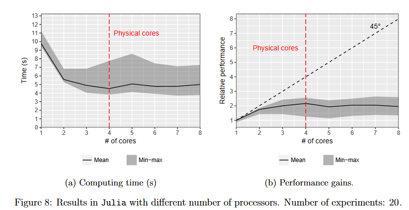

https://www.sas.upenn.edu/~jesusfv/Guide_Parallel.pdf

## Accessing Linstat and Slurm

- The easiest way to log in to Linstat/Slurm is to first log on to Winstat.
- You should have made a Winstat account/password at first-year orientation.

https://kb.wisc.edu/sscc/using-winstat

- You can log into Winstat with Citrix Workspace or at the following website. Web log-in cannot access local files.

https://winstat.ssc.wisc.edu/vpn/index.html

- If you need to reset your password:

https://www.sscc.wisc.edu/sscc_jsp/password/reset.jsp

## Linstat Cheat Sheet

- Open interactive julia REPL.

```r
  julia
```

- Run a julia script file and send save output to text file.

```r
  julia script.jl > output.txt &
```

- Change working directory to a folder.

```r
  cd FolderPath
```

## Linstat Cheat Sheet (Continued)

- See jobs running on current Linstat server.

```r
  top
```

- To close top, press “q”.
- Stop a job PID that is currently running

```r
  kill PID
```

## Slurm Cheat Sheet

- To run a script file on slurm with N cores and M gb of memory:

```r
  ssubmit --cores=N --mem=Mg "julia script.jl"
```

- To figure out how much memory you need:
  1. Run your job on Linstat and check its memory use (RES).
  2. Then kill your job and send it to slurm.
- Slurm will send you an email when your job is done running.
- You can submit to specific partitions of the server using the option `--part`.

https://sscc.wisc.edu/sscc/pubs/grc/slurm.html#partitions-priorities

## Slurm Cheat Sheet (Continued)

- To see jobs that are running on slurm, use

```r
squeue -a
```

- To cancel your job:

```r
scancel JOBID
```

## Linstat vs. Slurm

- **Linstat** is good for:
  1. Interactive coding.
  2. Checking that your code runs on SSCC servers.
  3. See how much memory you are using.
  4. Sending jobs to slurm.
- **Slurm** is good for big jobs that need lots of cores and run for a long time.